# ERP Panorama

- Show All Code
- Hide All Code
- View Source

Authors

Dr. Raúl Trujillo

Jaime Bonilla

# 1 Lectura de los datos

```r
#| label: read_data
#| include: true
#| warning: false
#| echo: false
#| eval: true

erp_panorama_2020 <- read_csv(
  here::here("data", "erp_panorama_2020.csv"),
  show_col_types = FALSE
  ) |>
  mutate(
    timestamp = mdy_hm(timestamp),
    date = date(timestamp),
    hour = hour(timestamp),
    cat = ifelse( hour < 6 | 22 < hour, "Noche","Día" )
  )

n_rows <- count(erp_panorama_2020)


erp_panorama_2020 <- erp_panorama_2020 |>
  filter(p1 > 0 & p2 >0 & (p1-p2>0)) |>
  filter(between(flow, 1.5, 60)) |>
  mutate(
    kv    = round(kv(p1/10, p2/10, flow*3.6, params$temperature),3),
    sigma = round(sigma_1(p1/10, p2/10, params$elevation, params$temperature),3),
    zeta  = zeta_vaule(params$diameter, kv),
    flow  = round(flow,0),
    delta_sp = p2 - setpoint
  ) |>
  na.omit() |>
   select(timestamp, date, hour, cat, p1, p2, flow, setpoint, delta_sp, kv, sigma, zeta)
```

**Lecturas removidas**

# 2 Análisis inicial de los datos (visualización exploratoria)

## 2.1 Histograma de Flujos

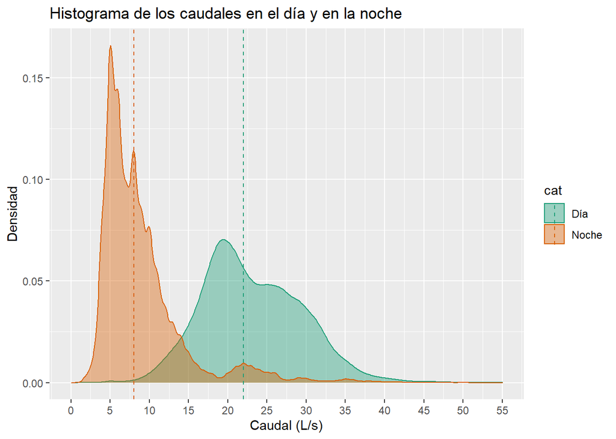

Gráfico de caudales en el día y en la noche

````markdown
```{r}
#| label: histogram_flow
#| output-location: column
#| fig-cap: "Gráfico de caudales en el día y en la noche"
#| warning: false

# https://www.tidyverse.org/blog/2020/03/dplyr-1-0-0-summarise/
# https://r-graph-gallery.com/82-boxplot-on-top-of-histogram.html

mu <- erp_panorama_2020 |>
  group_by(cat) |>
  summarise(grp.median = median(flow))

erp_panorama_2020 |>
  ggplot(aes(x = flow, fill = cat, color = cat)) +
    geom_density(
      alpha = 0.4,
      position = "identity"
    ) +
  geom_vline(
    data=mu,
    aes(xintercept = grp.median, color = cat),
    linetype="dashed"
  ) +
  scale_color_brewer(palette="Dark2")+
  scale_fill_brewer(palette="Dark2") +
  ggtitle("Histograma de los caudales en el día y en la noche") +
  xlab("Caudal (L/s)") +
  ylab("Densidad") +
  scale_x_continuous(
    limits = c(0, 55),
    breaks = seq(0, 55, by = 5)
  )
```
````

**Caudales medios en el día y la noche**

- Se especificó como consumo diario los consumos entre las 6:00 y las 22:00 horas
- El consumo medio (mediana) diario fue de 22 $l/s$
- El consumo medio (mediana) nocturno fue de 8 $l/s$

### 2.1.1 Diagrama de de caja (Box-Plots) de los flujos horarios

El diagrama de de caja es una forma rápida y fácil de visualizar datos complejos donde tiene varias muestras.

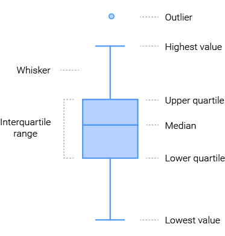

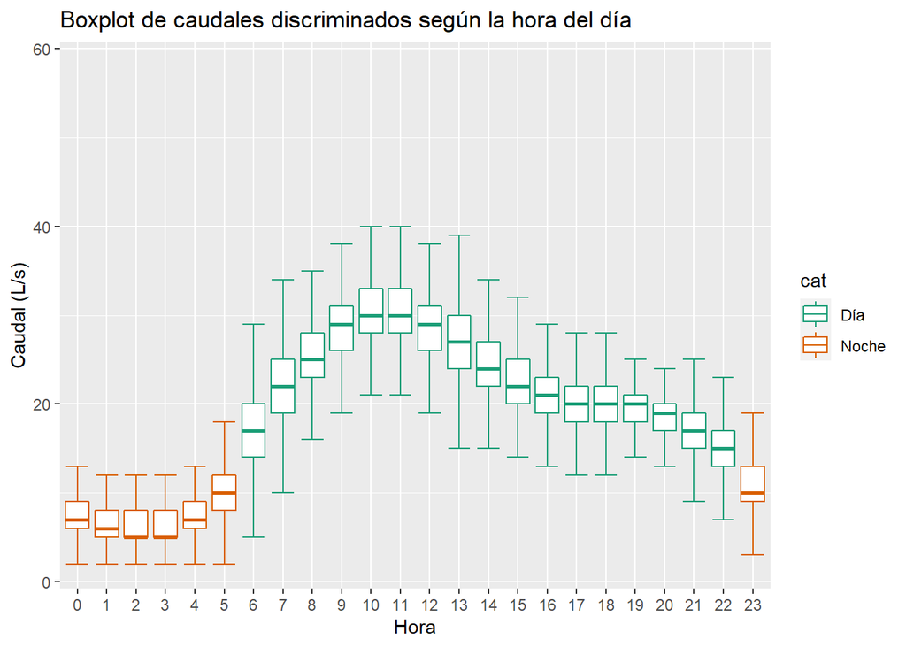

Boxplot de flujos por horas

````markdown
```{r}
#| label: histogram_hour_flow
#| output-location: column
#| fig-cap: "Boxplot de flujos por horas"
#| warning: false

erp_panorama_2020 |>
    ggplot(aes(x= as.factor(hour), y=flow, color=cat)) +
    stat_boxplot(geom = "errorbar") +
    geom_boxplot(width = 0.8, outlier.shape = NA) +
    scale_color_brewer(palette="Dark2") +
  ggtitle("Boxplot de caudales discriminados según la hora del día") +
  xlab("Hora") +
  ylab("Caudal (L/s)")
```
````

## 2.2 Histograma de la Consigna de presión (Set-point) verzus presión aguas abajo

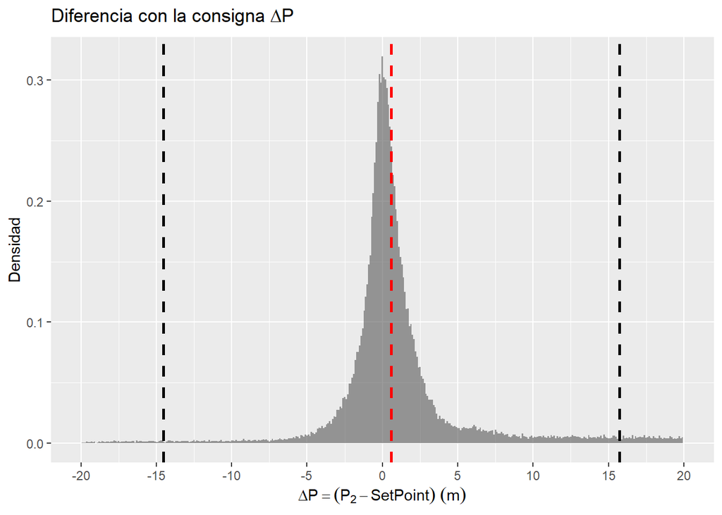

Histograma de la Consigna de presión verzus presión aguas abajo

````markdown
```{r}
#| label: histogram_delta_setpoint
#| output-location: column
#| fig-cap: "Histograma de la Consigna de presión verzus presión aguas abajo"
#| warning: false

erp_panorama_2020 |>
  ggplot(aes(x = delta_sp)) +
    geom_histogram(
      aes(y=..density..),
      position="identity",
      alpha=0.6,
      binwidth = 0.1
    ) +
    labs(title = TeX(r'(Diferencia con la consigna $\Delta P$)')) +
    xlab(TeX(r'($\Delta P = (P_2 - SetPoint)$ $(m)$)')) +
    ylab("Densidad") +
    scale_x_continuous(
      limits = c(-20, 20),
      breaks = seq(-20, 20, by = 5)
    ) +
    geom_vline(aes(xintercept = median(delta_sp)), color = "red", size = 1, linetype = "dashed") +
    geom_vline(aes(xintercept = median(delta_sp) + sd(delta_sp)), color = "#000000", size = 1, linetype = "dashed") +
    geom_vline(aes(xintercept = median(delta_sp) - sd(delta_sp)), color = "#000000", size = 1, linetype = "dashed")
```
````

## 2.3 Coeficiente de flujo $K_v$

El valor $K_v$ mide el caudal ($m^3/hour$) a través de una válvula para una caída de presión dada ($1\;bar$). Cuanto mayor sea este valor, mayor será el caudal a través de la válvula a una caída de presión dada. Por lo general, los valores $K_v$ son proporcionados en la descripción en la hoja de datos del productor. La situación particular con una válvula completamente abierta determina el valor $K_{vs}$.

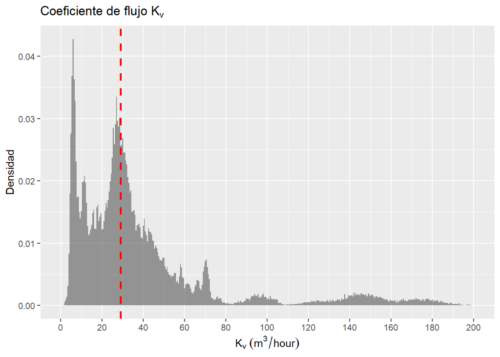

Histograma del Coeficiente de flujo Kv

````markdown
```{r}
#| label: histogram_flow_coefficient
#| output-location: column
#| fig-cap: "Histograma del Coeficiente de flujo Kv"
#| warning: false
#|
# https://www.tidyverse.org/blog/2020/03/dplyr-1-0-0-summarise/
# https://cran.r-project.org/web/packages/latex2exp/vignettes/using-latex2exp.html

erp_panorama_2020 |>
  ggplot(aes(x = kv)) +
    geom_histogram(
      aes(y=..density..),
      position="identity",
      alpha=0.6,
      binwidth = 0.5
    ) +
    labs(title = TeX(r'(Coeficiente de flujo $K_v$)')) +
    xlab(TeX(r'($K_v$ $(m^3/hour)$)')) +
    ylab("Densidad") +
    scale_x_continuous(
      limits = c(0, 200),
      breaks = seq(0, 200, by = 20)
    ) +
    geom_vline(aes(xintercept = median(kv)), color = "red", size = 1, linetype = "dashed" )
```
````

## 2.4 Historram del factor de Zeta de la válvula

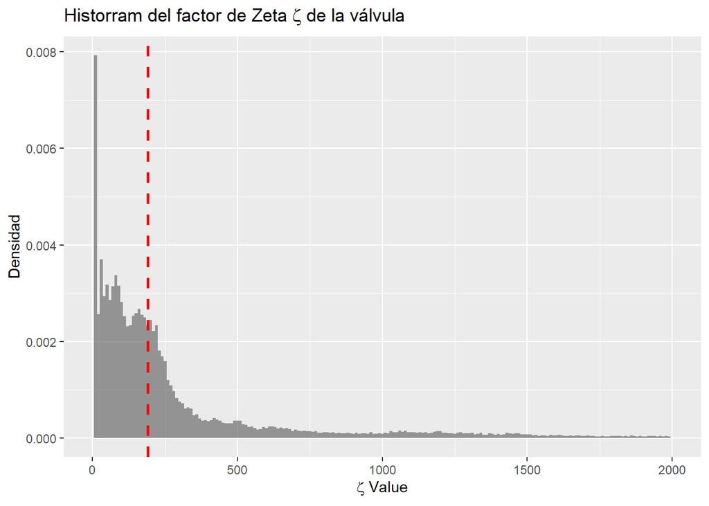

Historram del factor de Zeta de la válvula

````markdown
```{r}
#| label: histogram_zeta_value
#| output-location: column
#| fig-cap: "Historram del factor de Zeta de la válvula"
#| warning: false
#|

erp_panorama_2020 |>
  ggplot(aes(x = zeta)) +
    geom_histogram(
      aes(y=..density..),
      position="identity",
      alpha=0.6,
      binwidth = 10
    ) +
    labs(title = TeX(r'(Historram del factor de Zeta $\zeta$ de la válvula)')) +
    xlab(TeX(r'($\zeta$ Value)')) +
    ylab("Densidad") +
    scale_x_continuous(
      limits = c(0, 2000),
      breaks = seq(0, 2000, by = 500)
    ) +
    geom_vline(aes(xintercept = median(zeta)), color = "red", size = 1, linetype = "dashed" )
```
````

## 2.5 Relación caudal versus Presión Aguas Arriba (P1) de la válvula

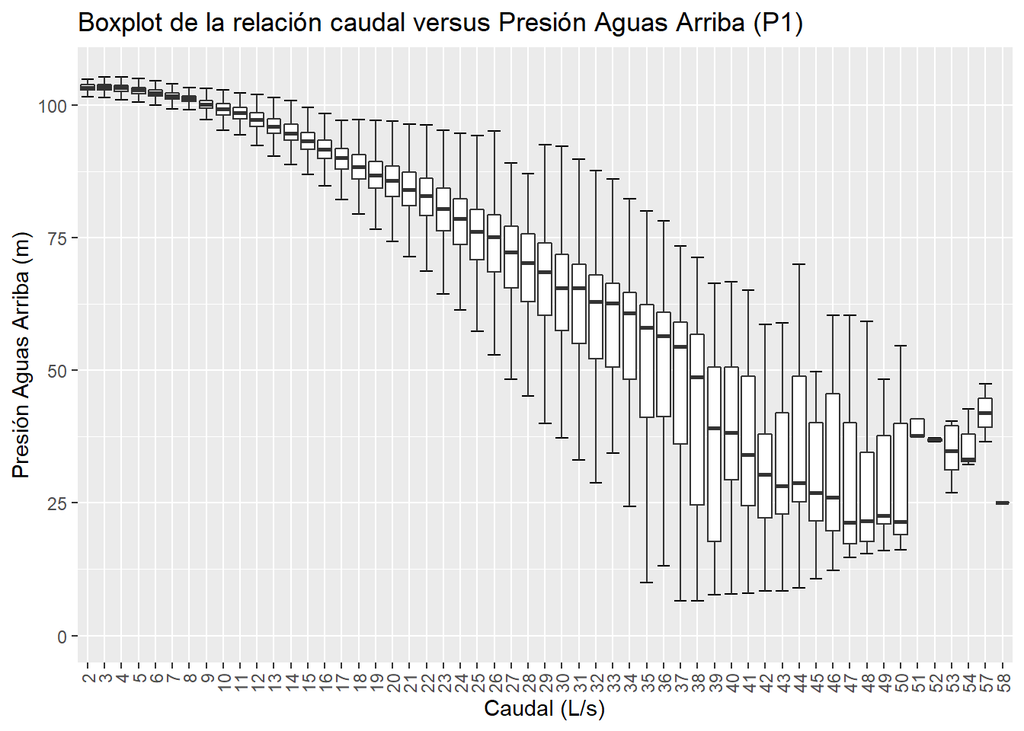

Boxplot de la relación caudal Presión Aguas Arriba (P1) de la válvula

````markdown
```{r}
#| label: flow_vs_p1
#| output-location: column
#| fig-cap: "Boxplot de la relación caudal Presión Aguas Arriba (P1) de la válvula"
#| warning: false
#|
erp_panorama_2020 |>
  ggplot(aes(x= as.factor(flow), y=p1)) +
  stat_boxplot(geom = "errorbar") +
  geom_boxplot(width = 0.8, outlier.shape = NA) +
  theme(axis.text.x = element_text(angle = 90, vjust = 0.5, hjust=1)) +
  scale_color_brewer(palette="Dark2") +
  ggtitle("Boxplot de la relación caudal versus Presión Aguas Arriba (P1)") +
  xlab("Caudal (L/s)") +
  ylab("Presión Aguas Arriba (m)")
```
````

## 2.6 Consumo medio diario

```r
# https://www.youtube.com/watch?v=UBDevJvH1m4
# https://tbradley1013.github.io/2018/10/01/calculating-quantiles-for-groups-with-dplyr-summarize-and-purrr-partial/

daily.df1 <- erp_panorama_2020 |>
  group_by(date) |>
  summarise(
    q25 = quantile(flow, probs = 0.25, na.rm = TRUE),
    median = median(flow, na.rm = TRUE),
    mean = mean(flow, na.rm = TRUE),
    q75 = quantile(flow, probs = 0.75, na.rm = TRUE),
    sd = sd(flow, na.rm = TRUE),
    n = n(),
    missing = round(((24*60/5) - n)/(24*60/5)*100,2)
  ) |>
  filter(missing <= 75)
```